# Analysis of WTA & ATP Match Statistics (2020-2024)

BIOS 611 Project

2025-12-03

# 1 Data Overview

This analysis explores match statistics from the ATP (Men’s) and WTA (Women’s) tours from 2020 to 2024. The goal is to identify gender-based performance patterns, understand factors contributing to player success, and investigate outliers using unsupervised learning.

- **Data Sources:** Combined match data from ATP and WTA CSV files (2020-2024).
- **Sample Size:**
  - Total Players Analyzed: **784** (after filtering for players with $\ge$ 5 matches)
  - Breakdown: **394** ATP players, **390** WTA players.
  - Total Matches Processed: **25,140**
- **Features Analyzed:** Averages of Aces, Double Faults, Serve Points, 1st Serves In/Won, 2nd Serves Won, Break Points Saved/Faced.

# 2 Research Question A: Can Unsupervised Learning Distinguish Gender?

**Method:** Principal Component Analysis (PCA) followed by K-Means Clustering (K=2) on average game statistics.

## 2.1 PCA Results

The model effectively separates gender based on game statistics. The variables used in this analysis were: **Average Aces, Double Faults, Serve Points, 1st Serves In %, 1st Serve Points Won %, 2nd Serve Points Won %, Serve Games, Break Points Saved, and Break Points Faced**.

- **PC1 (50.4% variance):** Heavily driven by **Serve Power/Volume** (high loadings for Aces, Serve Games, 1st Serve Won).
- **PC2 (25.6% variance):** Relates to **Pressure/Resilience** (Break Points Faced/Saved).

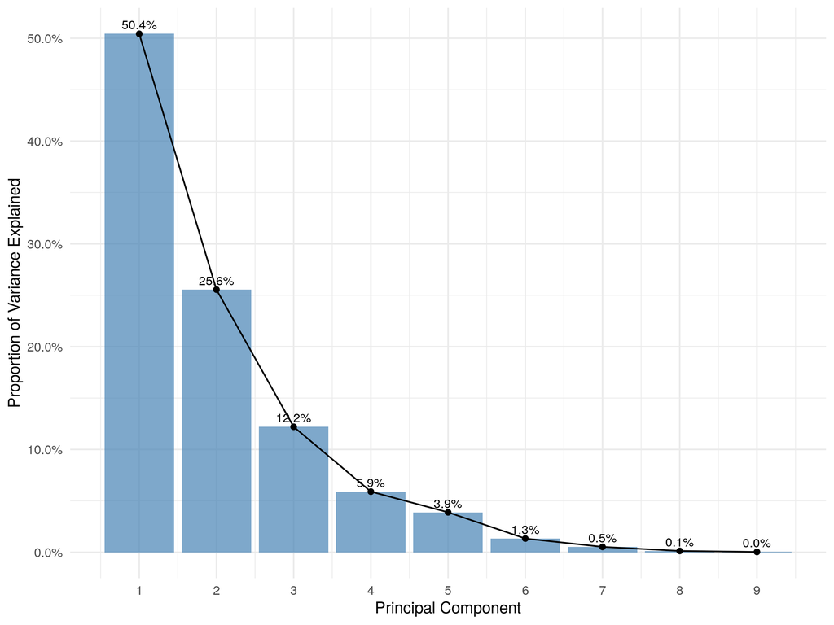

Figure 1. Scree Plot showing Variance Explained by Principal Components.

## 2.2 Clustering Performance

The unsupervised clustering algorithm (K-Means, K=2) achieved a high degree of accuracy in distinguishing player gender solely based on match statistics.

**Table 1. Contingency Table of Clustering Results by Gender**

|  | Cluster 1 (ATP-Leaning) | Cluster 2 (WTA-Leaning) |
| --- | --- | --- |
| **ATP** | 298 (Correct) | 96 (Mis-clustered) |
| **WTA** | 16 (Mis-clustered) | 374 (Correct) |

- **Accuracy:** The model correctly classified **672 out of 784** players, achieving an overall accuracy of **85.7%**.
- **Cluster 1 (ATP-Leaning):** Predominantly ATP players (298 vs 16 WTA).
- **Cluster 2 (WTA-Leaning):** Predominantly WTA players (374 vs 96 ATP).

This confirms that “men’s tennis” and “women’s tennis” have distinct statistical signatures, primarily driven by serve dominance.

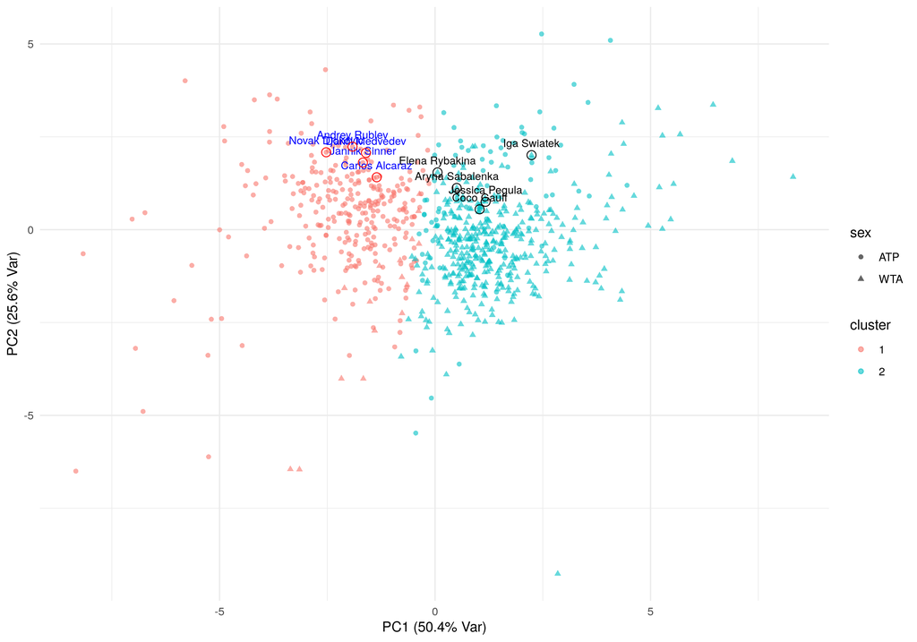

Figure 2. K-Means Clustering in PCA Space (PC1 vs PC2). Top 5 players in WTA and ATP labeled.

# 3 Research Question B: What kind of player wins?

**Method:** Correlation and Regression Analysis of Win Rate against Principal Components.

## 3.1 Interpretation of PCs via Loadings Plot

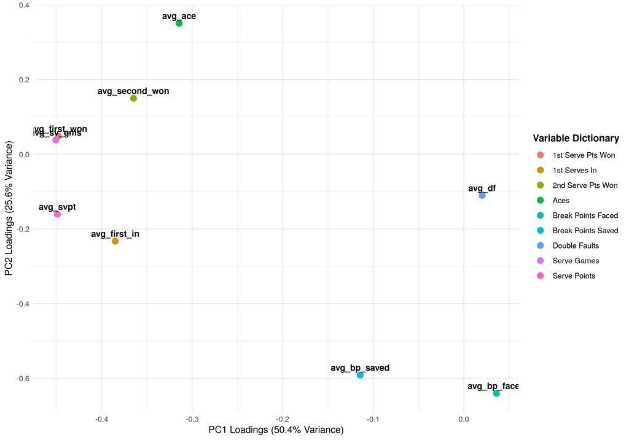

Figure 3. PCA Variable Loadings Vectors.

- **PC1 (Serve Quality/Volume):** In the loadings plot, variables like Aces (`avg_ace`), Serve Games (`avg_sv_gms`), and First Serve Points Won (`avg_first_won`) cluster heavily on the **negative** side (left). This means a *lower* (more negative) PC1 score represents stronger, more dominant serving stats.
- **PC2 (Pressure/Resilience):** The variables Break Points Faced (`avg_bp_faced`) and Saved (`avg_bp_saved`) have strong **negative** loadings (bottom of the plot). Consequently, a *higher* (positive) PC2 score indicates a player who faces *fewer* break points—a hallmark of dominance and control.

## 3.2 Correlation with Winning

- **PC1 vs Win Rate:** $r = -0.1280$ ($p < 0.001$).
  - Since strong serving corresponds to negative PC1, the negative correlation confirms that better servers tend to win more, but the relationship is relatively weak.
- **PC2 vs Win Rate:** $r = 0.2794$ ($p < 1e-15$).
  - The strong positive correlation means that players with high PC2 scores (those who face fewer break points) are significantly more likely to win.
- **Key Insight:** While serve power (PC1) matters, the ability to control the match and avoid break points (PC2) is the stronger statistical driver of victory.

## 3.3 Visual Evidence

The win rate heatmap in PCA space shows that the “winningest” players tend to cluster in regions with high PC2 scores (top of the chart). The top 5 ranked players (shown in Figure 2) also align with these high-win-rate regions.

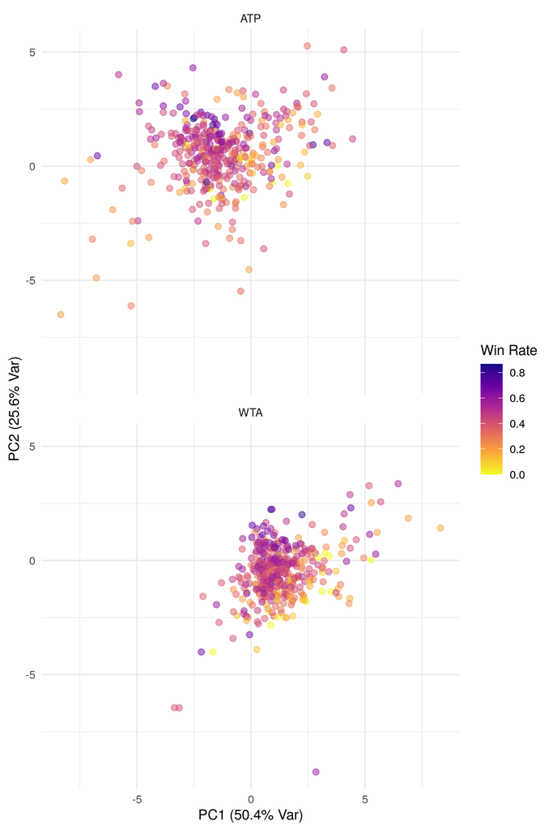

Figure 4. Player Win Rates in PCA Space by Tour.

# 4 Research Question C: Mis-clustered Player Analysis

**Method:** Analysis of the 112 players (14%) who were “misclassified” by the clustering algorithm (e.g., ATP players in the “WTA-like” cluster).

## 4.1 Why are they mis-clustered?

### 4.1.1 WTA in ATP Cluster (n=16)

These players play a “power game” more typical of the ATP tour.

- **Aces:** They hit significantly more Aces (Avg 3.36) than typical WTA players (Avg 2.03).
- **Serve Dominance:** They win significantly more points on their first serve (33.5%) compared to the WTA average (26.4%), mirroring ATP efficacy.

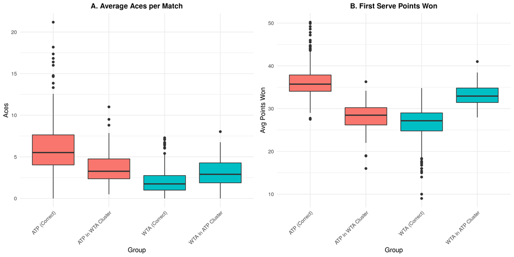

Figure 5. Comparison of Service Metrics for Correct vs. Mis-clustered Players. (A) Distribution of Aces per Match. (B) Distribution of First Serve Points Won.

### 4.1.2 ATP in WTA Cluster (n=96)

These players have statistical profiles closer to the WTA average.

- **Aces:** They hit significantly fewer Aces (Avg 3.64) than typical ATP players (Avg 6.08).
- **Serve Effectiveness:** Their points won on first serve (27.9) drops drastically from the ATP standard (36.4) to near-WTA levels (26.4), indicating a lack of the “free points” usually associated with men’s tennis.
- **Performance Impact:** These “mis-clustered” ATP players have a significantly **lower win rate** (35%) compared to standard ATP players (42%).

### 4.1.3 Ranking scores

As shown in Figure 6, ATP players assigned to the “WTA-style” cluster have substantially lower ranking points than correctly clustered ATP players. This pattern is consistent with their match statistics: weaker serve performance and fewer aces make these ATP players resemble WTA profiles, and this “WTA-style” play is penalized heavily in the men’s game. On the women’s side, the pattern looks different. WTA players assigned to the “ATP-style” cluster do not suffer a corresponding drop; in fact, their ranking points are comparable to correctly clustered WTA players. This indicates that adopting an “ATP-style” power-serve profile is not a disadvantageor WTA players, whereas adopting a “WTA-style” lower-serve-impact profile is a clear disadvantage for ATP players.

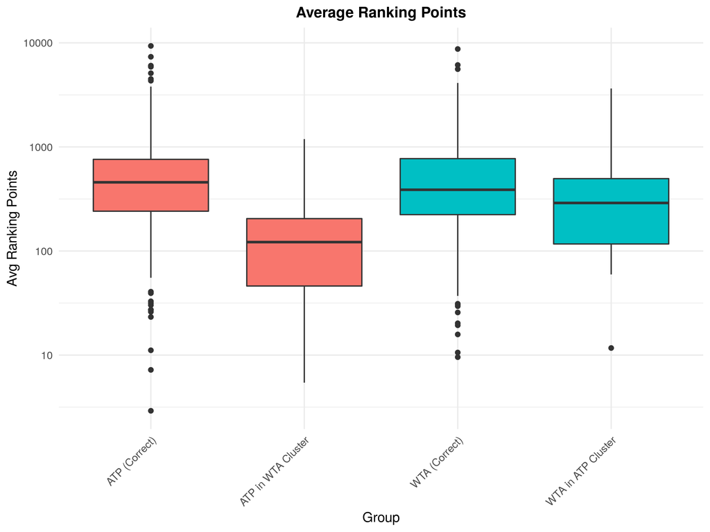

Figure 6. Distribution of Average Ranking Points by Cluster Group. Note that ATP players in the WTA cluster (“ATP in WTA Cluster”) show a trend towards lower ranking points compared to the correct ATP group.